# Keyforge Deck Name Analysis

## Words in Keyforge decks are exclusive to certain houses.

Based on a [Reddit thread](https://www.reddit.com/r/KeyforgeGame/comments/a3q5wh/brad_andres_just_confirmed_of_a_direct/) that pointed me to a particularity of the [Keyforge](http://keyforgegame.com) deck name generation algorithm, I have done an analysis of [every Keyforge deck](https://drive.google.com/drive/folders/1Yk4x221rqeIr32WrC5hkMXyBmWC311rS) (provided by [Decks Of Keyforge](http://decksofkeyforge.com)) and found all the words exclusive to a certain Keyforge house!

Below are charts that show the top 30 exclusive words for a house, and how many deck names have those words in them.

All words below are 100% exclusive to their house.

I have uploaded the full dataset to explore at [this google drive folder](https://drive.google.com/drive/folders/1wMMx1EjgFfOiqtecG7UOv3_G2_VvbK5f?usp=sharing) as well as slightly prettier versions of these graphs.

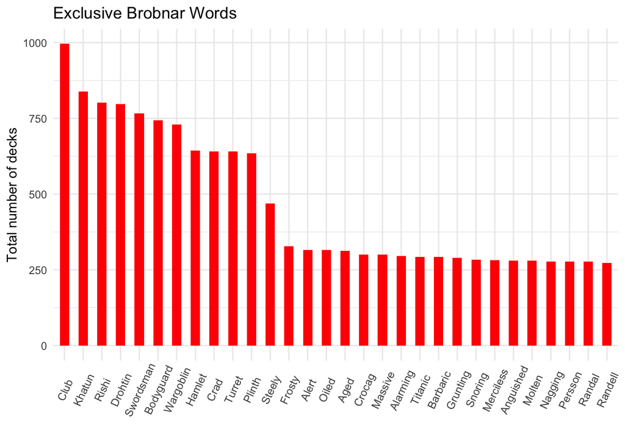

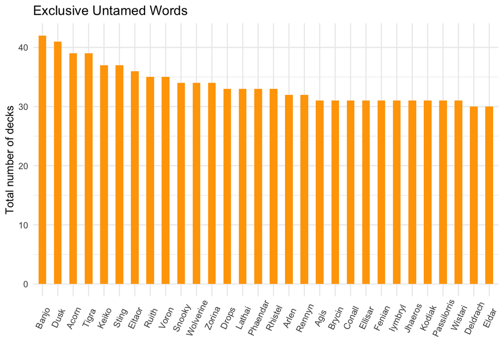

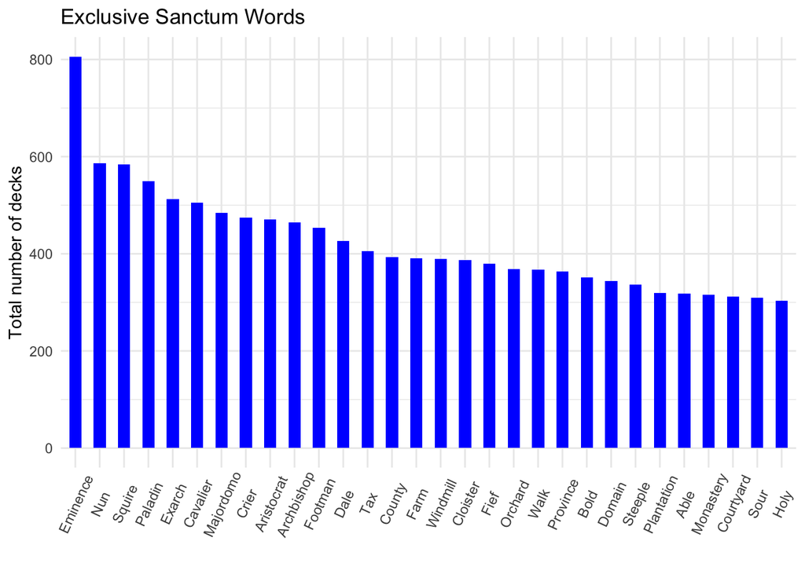

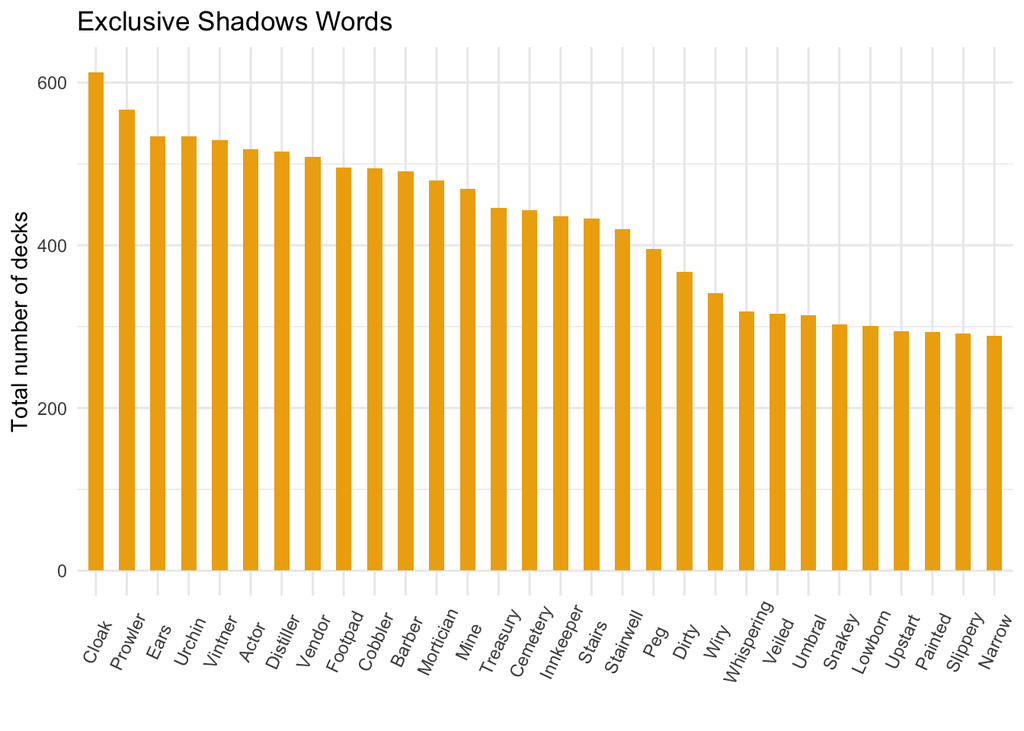

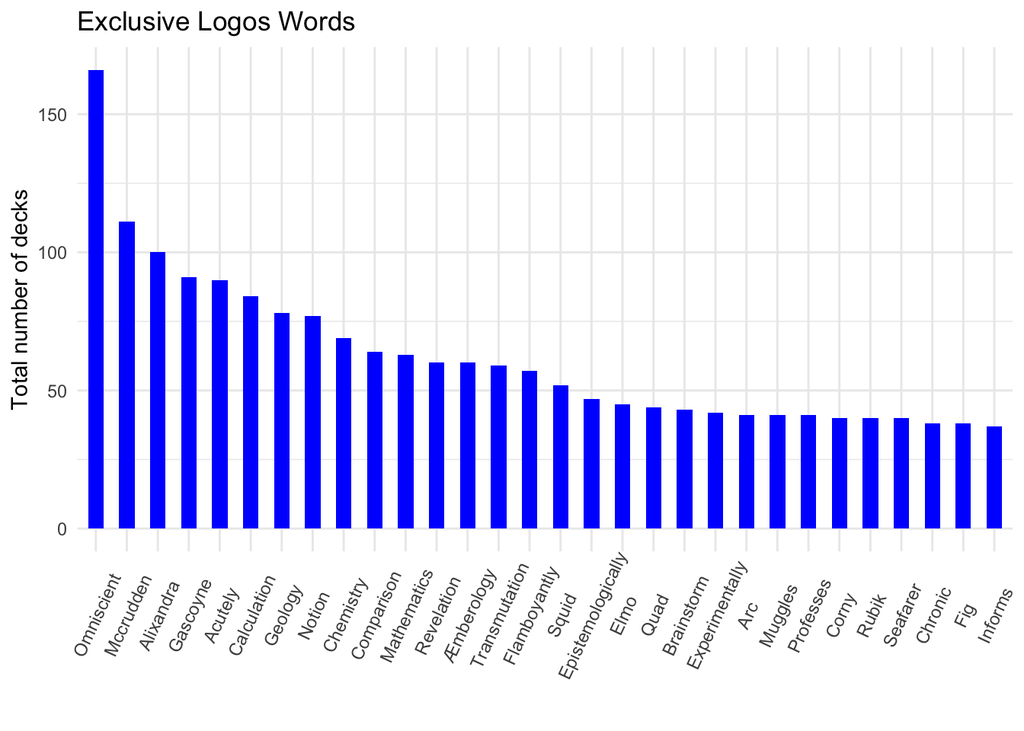

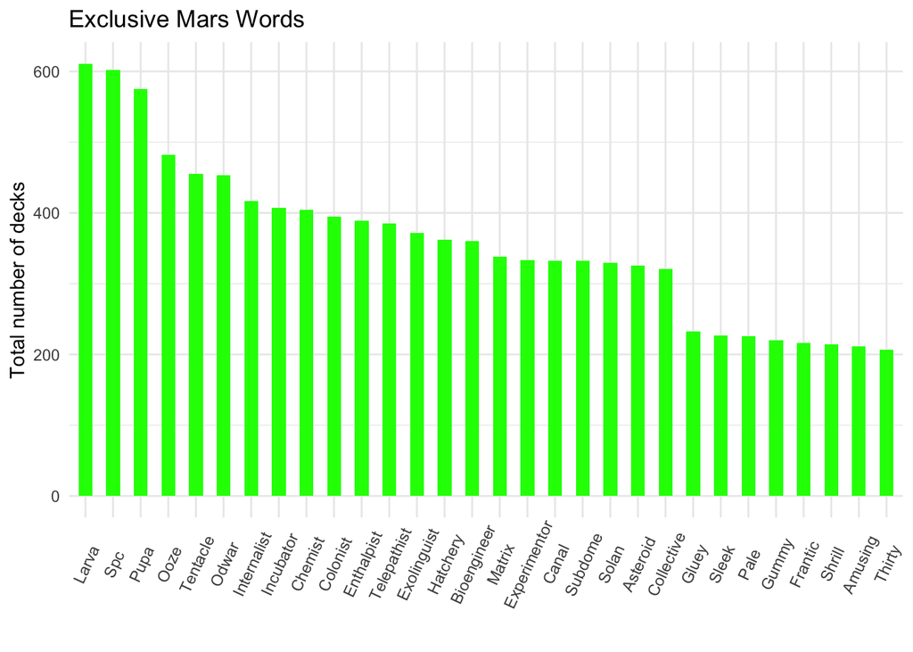

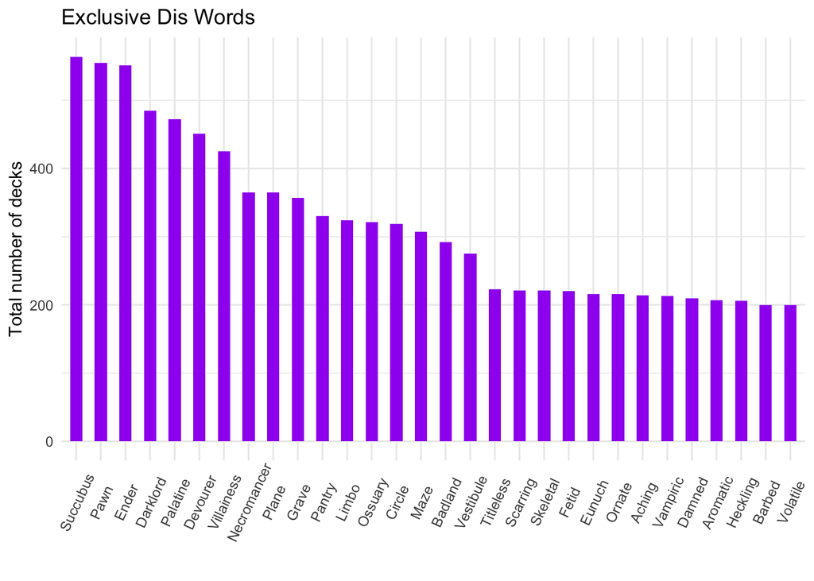

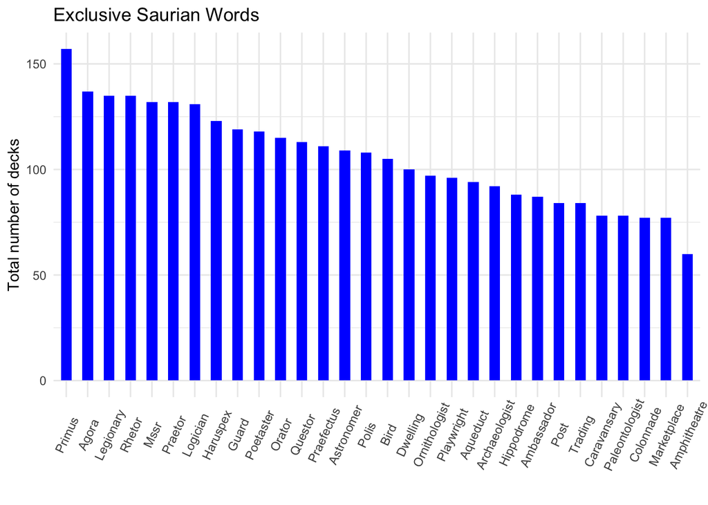

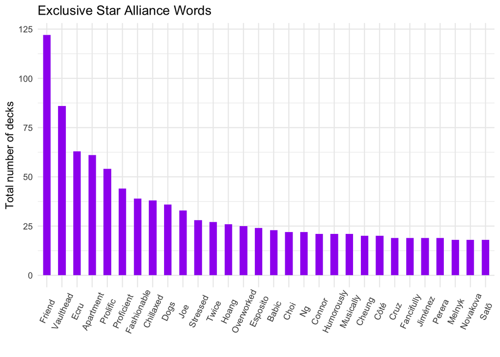

There’s further analysis to be done here. I noticed that certain words are *nearly* exclusive to a house, but not entirely. I should be able to get a p-value for a confidence threshold for “exclusivity”, but I got a lil stuck on the probability math.

There’s a full data dump of every parsed word and their house sums and percentages on the google drive folder linked above if anyone wants to put in the work to figure that out. :)

As well, I applied this same analysis to see if certain words are exclusive to certain *cards*, but came up empty. Perhaps an “exclusivity confidence” analysis might shed some light here.

Once I get around to it, I plan on adding on adding some interactivity to these charts, as well as adding a “Deck Name Analyzer” to show if your deck contains any exclusive words in it.

If anyone finds anything interesting to share, or finds anything wrong with my reports, feel free to reach out to me on [Reddit](https://www.reddit.com/user/MetroidMcCloud) or [Twitter](https://twitter.com/TimothySikes).

Share and Enjoy!